# hw2_data505

Author

Chloe Bui

Published

January 31, 2025

## Prepare the data

```r
library(tidyverse)
library(caret)
library(fastDummies)
wine <- readRDS(gzcon(url("https://github.com/cd-public/D505/raw/master/dat/wine.rds")))
```

**Explanation:**

> *1.loads the tidyverse package*

> *2.load the caret package*

> *3.load the fastDummies package*

> *4.reads a compressed RDS file directly from a URL*

## Feature Engineering

We begin by engineering an number of features.

1. Create a total of 10 features (including points).
2. Remove all rows with a missing value.
3. Ensure only log(price) and engineering features are the only columns that remain in the `wino` dataframe.

```r
wino = wine %>%
  mutate(lprice=log(price)) %>%                    # feature 1
  mutate(country = fct_lump(country, 3)) %>%       # feature 2:4
  mutate(variety = fct_lump(variety, 3)) %>%       # feature 5:7
  mutate(winery = fct_lump(winery, 3)) %>%         # feature 8:10
  select(lprice, points, country, variety, winery) %>%
  drop_na(.)

head(wino)
```

```
# A tibble: 6 × 5
  lprice points country variety    winery
   <dbl>  <dbl> <fct>   <fct>      <fct>
1   2.71     87 Other   Other      Other
2   2.64     87 US      Other      Other
3   2.56     87 US      Other      Other
4   4.17     87 US      Pinot Noir Other
5   2.71     87 Other   Other      Other
6   2.77     87 Italy   Other      Other
```

**Explanation:**

> *1. create a new feature as the logarithm of price column*

> *2. collapse the country/variety/winery factor into the top 3 most frequent levels and combines all others into an “Other” category*

> *4. remove rows with missing value*

```r
renamer <- function(s) {
  s %>% tolower() %>% str_replace("-| ", "_")}

wino <- wino %>%
  dummy_cols(remove_selected_columns = TRUE) %>%
  rename_with(.fn = renamer) %>%
  select(-ends_with("other"))

head(wino)
```

```
# A tibble: 6 × 11
  lprice points country_france country_italy country_us variety_chardonnay
   <dbl>  <dbl>          <int>         <int>      <int>              <int>
1   2.71     87              0             0          0                  0
2   2.64     87              0             0          1                  0
3   2.56     87              0             0          1                  0
4   4.17     87              0             0          1                  0
5   2.71     87              0             0          0                  0
6   2.77     87              0             1          0                  0
# ℹ 5 more variables: variety_pinot_noir <int>, variety_red_blend <int>,
#   `winery_chateau_ste. michelle` <int>, winery_dfj_vinhos <int>,
#   `winery_wines_& winemakers` <int>
```

**Explanation:**

> *2. Convert categorical variables into dummy columns while removing the original categorical columns.*

> *3. Rename all column names by applying the `renamer` function*

> *4. Remove columns that end with “other”*

## Caret

We now use a train/test split to evaluate the features.

1. Use the Caret library to partition the wino dataframe into an 80/20 split.
2. Run a linear regression with bootstrap resampling.
3. Report RMSE on the test partition of the data.

```r
# Partition
wine_index <- createDataPartition(wino$lprice, p = 0.8, list = FALSE)
wino_tr <- wino[wine_index, ]
wino_te <- wino[-wine_index, ]
```

**Explanation:**

> *Randomly split the data to 2 data sets: 80% data for training and 20% for testing*

```r
# linear regression with bootstrap resampling
do_training2 <- function(df, formula) {
  train(
    formula,
    data = df,
    method = "lm",
    trControl = trainControl(method = "boot", number = 10))}

mod <- do_training2(
  wino_tr, lprice ~ .)

mod
```

```
Linear Regression

71603 samples
   10 predictor

No pre-processing
Resampling: Bootstrapped (10 reps)
Summary of sample sizes: 71603, 71603, 71603, 71603, 71603, 71603, ...
Resampling results:

  RMSE       Rsquared   MAE
  0.4920249  0.4373884  0.3814483

Tuning parameter 'intercept' was held constant at a value of TRUE
```

**Explanation:**

> *1. Build function do_training2 using bootstrap resampling with 10 bootstrap iterations*

> *2. Fit the model to the training data set*

```r
# Report RMSE on the test partition of the data
postResample(
  pred = predict(mod, wino_te),
  obs = wino_te$lprice)
```

```
     RMSE  Rsquared       MAE
0.4944288 0.4320147 0.3852109
```

**Explanation:**

> *Predict the log(price) of testing data set based on the trained model “mod”*

## Variable Selection

We now graph the importance of your 10 features

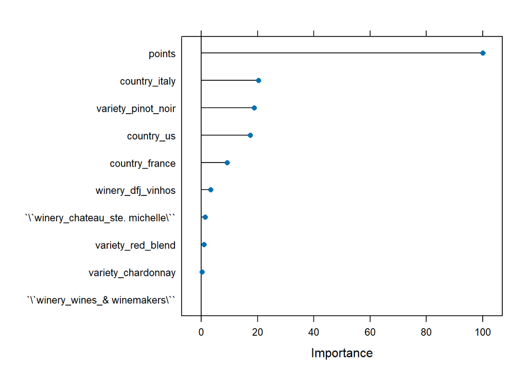

```r
plot(varImp(mod, scale = TRUE))
```